# nÜkraine slides

## Volunteering in the times of war: what data can tell us

### How many people in Ukraine become volunteers since 24.02

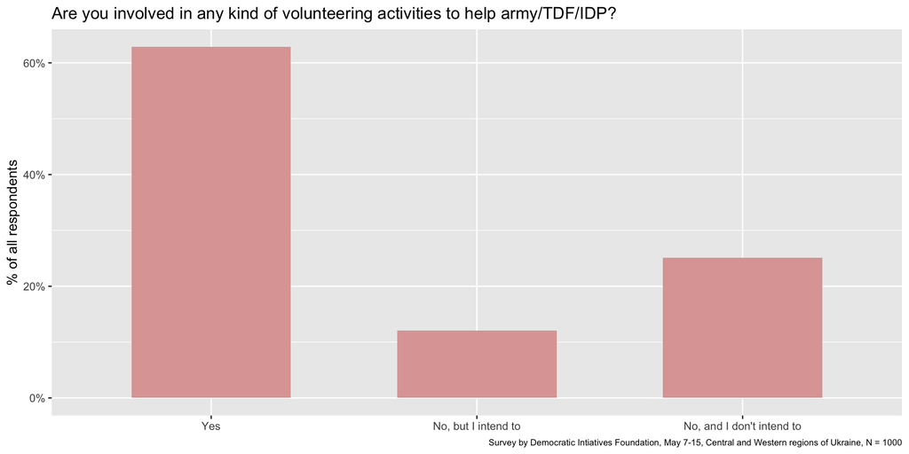

### How many volunteers lost their jobs

- Around a half of those who volunteered did not lose their jobs.
- Up to 12% of volunteers said they lost their jobs.
- Another 17% of them did not lose their jobs because they did not have ones.

### How many volunteers lost their jobs

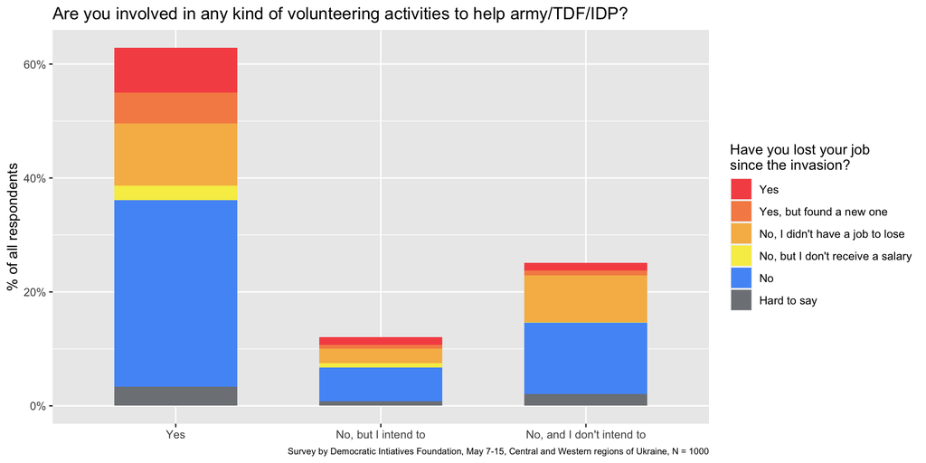

### How many volunteers came back to work beacuse they were out of money

- NO INFO found

### How many NGO were created

- Prior to the Russian invasion of Ukraine there [were](https://www.humanitarianoutcomes.org/sites/default/files/publications/ukraine_review_2022.pdf) about **150 active national NGOs** involved in humanitarian aid.
- Three months after February 24, approximately **2400 new groups** [were registered](https://business.diia.gov.ua/cases/novini/ukrainskij-biznes-v-umovah-vijni-analitika-stanu-za-3-misaci) as “charitable foundations or public organisations”.

### How much money were donated by people of different countries to Ukraine

- Since February 24, 992 grants worth $1,228,860,746 [were donated](https://topics.candid.org/issue-pages/ukraine/#tab-nav) to Ukraine.